# Collaboration and Competition

You are welcome to use this coding environment to train your agent for the project. Follow the instructions below to get started!

### 1. Start the Environment

Run the next code cell to install a few packages. This line will take a few minutes to run!

```python
!pip -q install ./python
```

```
tensorflow 1.7.1 has requirement numpy>=1.13.3, but you'll have numpy 1.12.1 which is incompatible.
ipython 6.5.0 has requirement prompt-toolkit<2.0.0,>=1.0.15, but you'll have prompt-toolkit 3.0.5 which is incompatible.
```

The environment is already saved in the Workspace and can be accessed at the file path provided below.

```python
from maddpg_agent import Agent
from collections import deque
import matplotlib.pyplot as plt
import numpy as np
import random
import time
import torch
from unityagents import UnityEnvironment

%matplotlib inline

env = UnityEnvironment(file_name="/data/Tennis_Linux_NoVis/Tennis")
```

```
INFO:unityagents:
'Academy' started successfully!
Unity Academy name: Academy
        Number of Brains: 1
        Number of External Brains : 1
        Lesson number : 0
        Reset Parameters :

Unity brain name: TennisBrain
        Number of Visual Observations (per agent): 0
        Vector Observation space type: continuous
        Vector Observation space size (per agent): 8
        Number of stacked Vector Observation: 3
        Vector Action space type: continuous
        Vector Action space size (per agent): 2
        Vector Action descriptions: ,
```

Environments contain *brains* which are responsible for deciding the actions of their associated agents. Here we check for the first brain available, and set it as the default brain we will be controlling from Python.

```python
# get the default brain
brain_name = env.brain_names[0]
brain = env.brains[brain_name]
```

### 2. Examine the State and Action Spaces

Run the code cell below to print some information about the environment.

```python
# reset the environment
env_info = env.reset(train_mode=True)[brain_name]

# number of agents
num_agents = len(env_info.agents)
print('Number of agents:', num_agents)

# size of each action
action_size = brain.vector_action_space_size
print('Size of each action:', action_size)

# examine the state space
states = env_info.vector_observations
state_size = states.shape[1]
print('There are {} agents. Each observes a state with length: {}'.format(states.shape[0], state_size))
print('The state for the first agent looks like:', states[0])
```

```
Number of agents: 2
Size of each action: 2
There are 2 agents. Each observes a state with length: 24
The state for the first agent looks like: [ 0.          0.          0.          0.          0.          0.          0.
  0.          0.          0.          0.          0.          0.          0.
  0.          0.         -6.65278625 -1.5        -0.          0.
  6.83172083  6.         -0.          0.        ]
```

### 3. Take Random Actions in the Environment

In the next code cell, you will learn how to use the Python API to control the agent and receive feedback from the environment.

Note that **in this coding environment, you will not be able to watch the agents while they are training**, and you should set `train_mode=True` to restart the environment.

```python
for i in range(5):                                         # play game for 5 episodes
    env_info = env.reset(train_mode=False)[brain_name]     # reset the environment
    states = env_info.vector_observations                  # get the current state (for each agent)
    scores = np.zeros(num_agents)                          # initialize the score (for each agent)
    while True:
        actions = np.random.randn(num_agents, action_size) # select an action (for each agent)
        actions = np.clip(actions, -1, 1)                  # all actions between -1 and 1
        env_info = env.step(actions)[brain_name]           # send all actions to tne environment
        next_states = env_info.vector_observations         # get next state (for each agent)
        rewards = env_info.rewards                         # get reward (for each agent)
        dones = env_info.local_done                        # see if episode finished
        scores += env_info.rewards                         # update the score (for each agent)
        states = next_states                               # roll over states to next time step
        if np.any(dones):                                  # exit loop if episode finished
            break
    print('Total score (averaged over agents) this episode: {}'.format(np.mean(scores)))

    agent = Agent(state_size=state_size, action_size=action_size, num_agents=num_agents, random_seed=0)
```

```
Total score (averaged over agents) this episode: -0.004999999888241291
Total score (averaged over agents) this episode: -0.004999999888241291
Total score (averaged over agents) this episode: -0.004999999888241291
Total score (averaged over agents) this episode: 0.04500000085681677
Total score (averaged over agents) this episode: -0.004999999888241291
```

When finished, you can close the environment.

```python
#env.close()
```

### 4. It's Your Turn!

Now it's your turn to train your own agent to solve the environment! A few **important notes**:

- When training the environment, set `train_mode=True`, so that the line for resetting the environment looks like the following:

  ```
  env_info = env.reset(train_mode=True)[brain_name]
  ```

- To structure your work, you're welcome to work directly in this Jupyter notebook, or you might like to start over with a new file! You can see the list of files in the workspace by clicking on *Jupyter* in the top left corner of the notebook.
- In this coding environment, you will not be able to watch the agents while they are training. However, *after training the agents*, you can download the saved model weights to watch the agents on your own machine!

```python
env_info = env.reset(train_mode=True)[brain_name]
```

```python
SOLVED_SCORE = 0.5
CONSEC_EPISODES = 100
PRINT_EVERY = 10
ADD_NOISE = True
```

```python
# MADDPG function

def maddpg(n_episodes=2000, max_t=1000, train_mode=True):
    """Multi-Agent Deep Deterministic Policy Gradient (MADDPG)

    Params
    ======
        n_episodes (int)      : maximum number of training episodes
        max_t (int)           : maximum number of timesteps per episode
        train_mode (bool)     : if 'True' set environment to training mode

    """
    scores_window = deque(maxlen=CONSEC_EPISODES)
    scores_all = []
    moving_average = []
    best_score = -np.inf
    best_episode = 0
    already_solved = False

    for i_episode in range(1, n_episodes+1):
        env_info = env.reset(train_mode=train_mode)[brain_name]         # reset the environment
        states = np.reshape(env_info.vector_observations, (1,48)) # get states and combine them
        agent_0.reset()
        agent_1.reset()
        scores = np.zeros(num_agents)
        while True:
            actions = get_actions(states, ADD_NOISE)           # choose agent actions and combine them
            env_info = env.step(actions)[brain_name]           # send both agents' actions together to the environment
            next_states = np.reshape(env_info.vector_observations, (1, 48)) # combine the agent next states
            rewards = env_info.rewards                         # get reward
            done = env_info.local_done                         # see if episode finished
            agent_0.step(states, actions, rewards[0], next_states, done, 0) # agent 1 learns
            agent_1.step(states, actions, rewards[1], next_states, done, 1) # agent 2 learns
            scores += np.max(rewards)                          # update the score for each agent
            states = next_states                               # roll over states to next time step
            if np.any(done):                                   # exit loop if episode finished
                break

        ep_best_score = np.max(scores)
        scores_window.append(ep_best_score)
        scores_all.append(ep_best_score)
        moving_average.append(np.mean(scores_window))

        # save best score
        if ep_best_score > best_score:
            best_score = ep_best_score
            best_episode = i_episode

        # print results
        if i_episode % PRINT_EVERY == 0:
            print('Episodes {:0>4d}-{:0>4d}\tMax Reward: {:.3f}\tMoving Average: {:.3f}'.format(
                i_episode-PRINT_EVERY, i_episode, np.max(scores_all[-PRINT_EVERY:]), moving_average[-1]))

        # determine if environment is solved and keep best performing models
        if moving_average[-1] >= SOLVED_SCORE:
            if not already_solved:
                print('<-- Environment solved in {:d} episodes! \
                \n<-- Moving Average: {:.3f} over past {:d} episodes'.format(
                    i_episode-CONSEC_EPISODES, moving_average[-1], CONSEC_EPISODES))
                already_solved = True
                # save weights
                torch.save(agent_0.actor_local.state_dict(), 'checkpoint_actor_0.pth')
                torch.save(agent_0.critic_local.state_dict(), 'checkpoint_critic_0.pth')
                torch.save(agent_1.actor_local.state_dict(), 'checkpoint_actor_1.pth')
                torch.save(agent_1.critic_local.state_dict(), 'checkpoint_critic_1.pth')
            elif ep_best_score >= best_score:
                print('<-- Best episode so far!\
                \nEpisode {:0>4d}\tMax Reward: {:.3f}\tMoving Average: {:.3f}'.format(
                i_episode, ep_best_score, moving_average[-1]))
                # save weights
                torch.save(agent_0.actor_local.state_dict(), 'checkpoint_actor_0.pth')
                torch.save(agent_0.critic_local.state_dict(), 'checkpoint_critic_0.pth')
                torch.save(agent_1.actor_local.state_dict(), 'checkpoint_actor_1.pth')
                torch.save(agent_1.critic_local.state_dict(), 'checkpoint_critic_1.pth')
            elif (i_episode-best_episode) >= 200:
                # stop training if model stops converging
                print('<-- Training stopped. Best score not matched or exceeded for 200 episodes')
                break
            else:
                continue

    return scores_all, moving_average
```

```python
def get_actions(states, add_noise):
    '''gets actions for each agent and then combines them into one array'''
    action_0 = agent_0.act(states, add_noise)    # agent 0 chooses an action
    action_1 = agent_1.act(states, add_noise)    # agent 1 chooses an action
    return np.concatenate((action_0, action_1), axis=0).flatten()
```

```python
agent_0 = Agent(state_size, action_size, num_agents=1, random_seed=0)
agent_1 = Agent(state_size, action_size, num_agents=1, random_seed=0)
```

```python
# Best Model

scores, avgs = maddpg()
```

```
Episodes 0000-0010	Max Reward: 0.100	Moving Average: 0.010
Episodes 0010-0020	Max Reward: 0.100	Moving Average: 0.015
Episodes 0020-0030	Max Reward: 0.000	Moving Average: 0.010
Episodes 0030-0040	Max Reward: 0.000	Moving Average: 0.008
Episodes 0040-0050	Max Reward: 0.100	Moving Average: 0.012
Episodes 0050-0060	Max Reward: 0.200	Moving Average: 0.017
Episodes 0060-0070	Max Reward: 0.100	Moving Average: 0.019
Episodes 0070-0080	Max Reward: 0.100	Moving Average: 0.020
Episodes 0080-0090	Max Reward: 0.100	Moving Average: 0.020
Episodes 0090-0100	Max Reward: 0.100	Moving Average: 0.021
Episodes 0100-0110	Max Reward: 0.100	Moving Average: 0.021
Episodes 0110-0120	Max Reward: 0.100	Moving Average: 0.023
Episodes 0120-0130	Max Reward: 0.100	Moving Average: 0.026
Episodes 0130-0140	Max Reward: 0.100	Moving Average: 0.030
Episodes 0140-0150	Max Reward: 0.100	Moving Average: 0.035
Episodes 0150-0160	Max Reward: 0.200	Moving Average: 0.039
Episodes 0160-0170	Max Reward: 0.100	Moving Average: 0.042
Episodes 0170-0180	Max Reward: 0.100	Moving Average: 0.045
Episodes 0180-0190	Max Reward: 0.100	Moving Average: 0.049
Episodes 0190-0200	Max Reward: 0.100	Moving Average: 0.052
Episodes 0200-0210	Max Reward: 0.100	Moving Average: 0.057
Episodes 0210-0220	Max Reward: 0.200	Moving Average: 0.059
Episodes 0220-0230	Max Reward: 0.100	Moving Average: 0.060
Episodes 0230-0240	Max Reward: 0.100	Moving Average: 0.058
Episodes 0240-0250	Max Reward: 0.100	Moving Average: 0.053
Episodes 0250-0260	Max Reward: 0.100	Moving Average: 0.053
Episodes 0260-0270	Max Reward: 0.100	Moving Average: 0.052
Episodes 0270-0280	Max Reward: 0.100	Moving Average: 0.052
Episodes 0280-0290	Max Reward: 0.100	Moving Average: 0.050
Episodes 0290-0300	Max Reward: 0.200	Moving Average: 0.053
Episodes 0300-0310	Max Reward: 0.200	Moving Average: 0.052
Episodes 0310-0320	Max Reward: 0.100	Moving Average: 0.053
Episodes 0320-0330	Max Reward: 0.100	Moving Average: 0.051
Episodes 0330-0340	Max Reward: 0.100	Moving Average: 0.056
Episodes 0340-0350	Max Reward: 0.200	Moving Average: 0.058
Episodes 0350-0360	Max Reward: 0.100	Moving Average: 0.054
Episodes 0360-0370	Max Reward: 0.100	Moving Average: 0.051
Episodes 0370-0380	Max Reward: 0.100	Moving Average: 0.046
Episodes 0380-0390	Max Reward: 0.200	Moving Average: 0.047
Episodes 0390-0400	Max Reward: 0.000	Moving Average: 0.038
```

[output cut: 88 more lines]

```
Episodes 1260-1270	Max Reward: 5.100	Moving Average: 0.808
Episodes 1270-1280	Max Reward: 2.500	Moving Average: 0.797
Episodes 1280-1290	Max Reward: 2.100	Moving Average: 0.786
Episodes 1290-1300	Max Reward: 2.500	Moving Average: 0.784
Episodes 1300-1310	Max Reward: 1.300	Moving Average: 0.610
Episodes 1310-1320	Max Reward: 3.100	Moving Average: 0.537
Episodes 1320-1330	Max Reward: 1.700	Moving Average: 0.561
Episodes 1330-1340	Max Reward: 0.500	Moving Average: 0.566
Episodes 1340-1350	Max Reward: 5.100	Moving Average: 0.644
Episodes 1350-1360	Max Reward: 5.100	Moving Average: 0.610
Episodes 1360-1370	Max Reward: 0.700	Moving Average: 0.503
Episodes 1370-1380	Max Reward: 2.300	Moving Average: 0.543
Episodes 1380-1390	Max Reward: 5.100	Moving Average: 0.722
Episodes 1390-1400	Max Reward: 4.300	Moving Average: 0.756
<-- Training stopped. Best score not matched or exceeded for 200 episodes
```

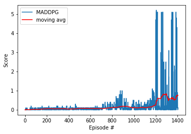

```python
import matplotlib.pyplot as plt
import numpy as np

# plot the scores
fig = plt.figure()
ax = fig.add_subplot(111)
plt.plot(np.arange(len(scores)), scores, label='MADDPG')
plt.plot(np.arange(len(scores)), avgs, c='r', label='moving avg')
plt.ylabel('Score')
plt.xlabel('Episode #')
plt.legend(loc='upper left');
plt.show()
```

```python
# 2nd best model

scores, avgs = maddpg()
```

```
Episodes 0000-0010	Max Reward: 0.300	Moving Average: 0.120
<-- Environment solved in -89 episodes!
<-- Moving Average: 0.555 over past 100 episodes
Episodes 0010-0020	Max Reward: 4.900	Moving Average: 0.400
<-- Best episode so far!
Episode 0023	Max Reward: 5.100	Moving Average: 0.596
<-- Best episode so far!
Episode 0024	Max Reward: 5.100	Moving Average: 0.783
<-- Best episode so far!
Episode 0026	Max Reward: 5.100	Moving Average: 0.919
<-- Best episode so far!
Episode 0027	Max Reward: 5.100	Moving Average: 1.074
Episodes 0020-0030	Max Reward: 5.100	Moving Average: 1.017
<-- Best episode so far!
Episode 0032	Max Reward: 5.100	Moving Average: 1.122
<-- Best episode so far!
Episode 0038	Max Reward: 5.100	Moving Average: 1.208
Episodes 0030-0040	Max Reward: 5.100	Moving Average: 1.218
<-- Best episode so far!
Episode 0041	Max Reward: 5.100	Moving Average: 1.312
Episodes 0040-0050	Max Reward: 5.100	Moving Average: 1.082
Episodes 0050-0060	Max Reward: 4.300	Moving Average: 0.998
<-- Best episode so far!
Episode 0066	Max Reward: 5.200	Moving Average: 1.026
Episodes 0060-0070	Max Reward: 5.200	Moving Average: 0.987
Episodes 0070-0080	Max Reward: 0.300	Moving Average: 0.875
Episodes 0080-0090	Max Reward: 2.300	Moving Average: 0.816
Episodes 0090-0100	Max Reward: 5.100	Moving Average: 0.821
Episodes 0100-0110	Max Reward: 5.200	Moving Average: 0.867
<-- Best episode so far!
Episode 0110	Max Reward: 5.200	Moving Average: 0.867
Episodes 0110-0120	Max Reward: 2.100	Moving Average: 0.846
Episodes 0120-0130	Max Reward: 3.000	Moving Average: 0.702
Episodes 0130-0140	Max Reward: 0.900	Moving Average: 0.550
Episodes 0140-0150	Max Reward: 4.900	Moving Average: 0.578
Episodes 0150-0160	Max Reward: 3.900	Moving Average: 0.595
Episodes 0160-0170	Max Reward: 1.900	Moving Average: 0.536
<-- Best episode so far!
Episode 0177	Max Reward: 5.200	Moving Average: 0.715
Episodes 0170-0180	Max Reward: 5.200	Moving Average: 0.732
<-- Best episode so far!
Episode 0185	Max Reward: 5.200	Moving Average: 0.810
Episodes 0180-0190	Max Reward: 5.200	Moving Average: 0.850
Episodes 0190-0200	Max Reward: 4.100	Moving Average: 0.872
Episodes 0200-0210	Max Reward: 4.700	Moving Average: 0.872
Episodes 0210-0220	Max Reward: 3.800	Moving Average: 0.879
Episodes 0220-0230	Max Reward: 2.700	Moving Average: 0.838
<-- Best episode so far!
Episode 0231	Max Reward: 5.200	Moving Average: 0.886
<-- Best episode so far!
Episode 0232	Max Reward: 5.200	Moving Average: 0.929
Episodes 0230-0240	Max Reward: 5.200	Moving Average: 0.994
Episodes 0240-0250	Max Reward: 3.500	Moving Average: 0.964
Episodes 0250-0260	Max Reward: 5.100	Moving Average: 1.079
<-- Training stopped. Best score not matched or exceeded for 200 episodes
```

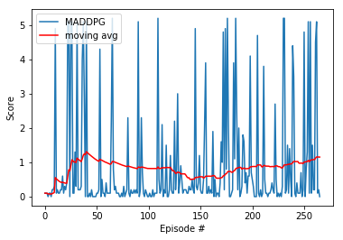

```python
# plot the scores
fig = plt.figure()
ax = fig.add_subplot(111)
plt.plot(np.arange(len(scores)), scores, label='MADDPG')
plt.plot(np.arange(len(scores)), avgs, c='r', label='moving avg')
plt.ylabel('Score')
plt.xlabel('Episode #')
plt.legend(loc='upper left');
plt.show()
```

```python
CONSEC_EPISODES = 10
PRINT_EVERY = 1
ADD_NOISE = False
```

```python
## reinitialize the agents (if needed)
agent_0 = Agent(state_size, action_size, num_agents=1, random_seed=0)
agent_1 = Agent(state_size, action_size, num_agents=1, random_seed=0)

# load the weights from file
agent_0_weights = 'checkpoint_actor_0.pth'
agent_1_weights = 'checkpoint_actor_1.pth'
agent_0.actor_local.load_state_dict(torch.load(agent_0_weights))
agent_1.actor_local.load_state_dict(torch.load(agent_1_weights))
```

```python
def test(n_episodes=10, max_t=1000, train_mode=False):

    scores_window = deque(maxlen=CONSEC_EPISODES)
    scores_all = []
    moving_average = []

    for i_episode in range(1, n_episodes+1):
        env_info = env.reset(train_mode=train_mode)[brain_name]         # reset the environment
        states = np.reshape(env_info.vector_observations, (1,48)) # get states and combine them
        scores = np.zeros(num_agents)
        while True:
            actions = get_actions(states, ADD_NOISE)           # choose agent actions and combine them
            env_info = env.step(actions)[brain_name]           # send both agents' actions together to the environment
            next_states = np.reshape(env_info.vector_observations, (1, 48)) # combine the agent next states
            rewards = env_info.rewards                         # get reward
            done = env_info.local_done                         # see if episode finished
            scores += np.max(rewards)                          # update the score for each agent
            states = next_states                               # roll over states to next time step
            if np.any(done):                                   # exit loop if episode finished
                break

        ep_best_score = np.max(scores)
        scores_window.append(ep_best_score)
        scores_all.append(ep_best_score)
        moving_average.append(np.mean(scores_window))

        # print results
        if i_episode % PRINT_EVERY == 0:
            print('Episodes {:0>4d}-{:0>4d}\tMax Reward: {:.3f}\tMoving Average: {:.3f}'.format(
                i_episode-PRINT_EVERY, i_episode, np.max(scores_all[-PRINT_EVERY:]), moving_average[-1]))

    return scores_all, moving_average
```

```python
scores, avgs = test()
```

```
Episodes 0000-0001	Max Reward: 5.200	Moving Average: 5.200
Episodes 0001-0002	Max Reward: 0.100	Moving Average: 2.650
Episodes 0002-0003	Max Reward: 5.200	Moving Average: 3.500
Episodes 0003-0004	Max Reward: 0.100	Moving Average: 2.650
Episodes 0004-0005	Max Reward: 0.300	Moving Average: 2.180
Episodes 0005-0006	Max Reward: 5.200	Moving Average: 2.683
Episodes 0006-0007	Max Reward: 0.000	Moving Average: 2.300
Episodes 0007-0008	Max Reward: 0.200	Moving Average: 2.038
Episodes 0008-0009	Max Reward: 5.200	Moving Average: 2.389
Episodes 0009-0010	Max Reward: 5.200	Moving Average: 2.670
```

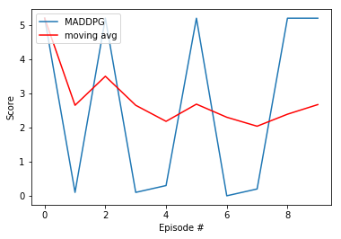

```python
# plot the scores
fig = plt.figure()
ax = fig.add_subplot(111)
plt.plot(np.arange(len(scores)), scores, label='MADDPG')
plt.plot(np.arange(len(scores)), avgs, c='r', label='moving avg')
plt.ylabel('Score')
plt.xlabel('Episode #')
plt.legend(loc='upper left');
plt.show()
```

```python
env.close()
```